# Lab 1

In this lab, we’ll replicate the sampling demonstration [at this website](http://www.zoology.ubc.ca/~whitlock/kingfisher/KFhomepage.htm). This will demonstrate using R to draw random numbers, calculate means, standard deviations, standard errors, and confidence intervals, and perform t-tests and power calculations.

You can go through this lab using the `Lab1.nb.html` document by highlighting the code in the code blocks and copying it into an R terminal. Or, you can go through the R Notebook file directly, running code in the code blocks directly.

## Part 1: Sampling from a normally distributed population

The first part of the demonstration explores the variability of sampling individuals from a larger population and measuring them to learn about the population’s mean and variance.

This is based on [this website](http://www.zoology.ubc.ca/~whitlock/kingfisher/SamplingNormal.htm).

### Normal distribution calculations in R

In the demonstration, we are interested in the length of fish in a pond (the population). We’re going to simulate a population of fish such that the fish lengths follow a normal distribution with mean: $\mu = 106$mm, and standard deviation: $\sigma = 30$mm.

R has four functions for the normal distribution. Look at the help page by typing `?dnorm`. They are:

- `rnorm(n, mean = 0, sd = 1)` This generates `n` independent random draws from the distribution.
- `qnorm(p, mean = 0, sd = 1, lower.tail = TRUE)` This is the *quantile function*. It replaces the critical value table. The default (with `lower.tail=TRUE`) is to give you the 100x`p`% quantile of the distribution, i.e., the critical value greater that 100x`p`% of random draws a normal distribution with specified mean and standard deviation. To get the upper quantile, change `lower.tail=FALSE`.
- `pnorm(q, mean = 0, sd = 1, lower.tail = TRUE)` This is the *distribution function*. This is the probability of drawing a value less (greater if `lower.tail=FALSE`) than `q` from a normal distribution with the specified mean and standard deviation.
- `dnorm(x, mean = 0, sd = 1)` This calculates the *density* (height) of the normal distribution with specified mean and standard deviation at the value `x`.

Pretty much every distribution in R has the same four functions, specified with `rDIST`, `qDIST`, `pDIST` and `dDIST`, with `DIST` replaced by the distribution name. But some, like the *t*, *chi square*, or *F* distribution have additional *arguments*, such as the degrees of freedom of the distribution.

### Step 1: Sample 1 individual

We can ask `R` to simulate the sampling of a single fish from this population using the `rnorm` function:

```r
rnorm(n = 1, mean = 106, sd = 30)
```

```
[1] 56.02055
```

> What size did you get? Enter your fish length in the zoom chat

> Try running the code several times. Do you get different numbers?

**Note** We usually specify normal distributions based on their variance ($\sigma^2$) rather than their standard deviation ($\sigma$), but `R` always specifies normal distributions based on the standard deviation

### Step 2: Sample 10 individuals

You could run the above code 10 times and write down the fish sizes from each sample. But R has two ways of doing this automatically:

Option 1: Use a loop:

```r
sample_of_fish = rep(NA, times=10)  # prepare a vector to record the 10 fish
for(fish_number in 1:10){   # a for-loop runs the code inside the {brackets} several times, each time changing the variable 'fish_number' to the next element of the list provided after the word "in". Here, this list is the numbers 1, 2, 3, ..., 10
  print(fish_number)  # prints the variable 'fish_number' for this run of the code
  sample_of_fish[fish_number] = rnorm(n = 1, mean = 106, sd = 30)  # samples a fish, and records it in the vector
}
```

```
[1] 1
[1] 2
[1] 3
[1] 4
[1] 5
[1] 6
[1] 7
[1] 8
[1] 9
[1] 10
```

```r
# We can print out the list of fish by just giving the variable name and running it
sample_of_fish
```

```
 [1] 131.27432 117.56519 170.15415 112.38397 161.21568  47.13403  74.01694
 [8] 110.98470  91.34007  81.88168
```

Option 2: Just ask for 10 fish!

```r
sample_of_fish = rnorm(n = 10, mean = 106, sd = 30)
sample_of_fish
```

```
 [1]  70.49874  89.82806  59.28791  85.84830 133.40726  82.98290 133.60812
 [8] 115.87582 117.92845  41.56392
```

Calculate the mean of your sample

```r
mean(sample_of_fish)
```

```
[1] 93.08295
```

> How close is this to the *true* mean of the population? Enter this in the zoom chat. What mean was closest to the true mean? What mean was farthest?

Make a histogram of these fish lengths

```r
hist(sample_of_fish, xlim = c(0,300),prob = T)

# add a line for the sample mean.
abline(v = mean(sample_of_fish),lwd = 2)
```

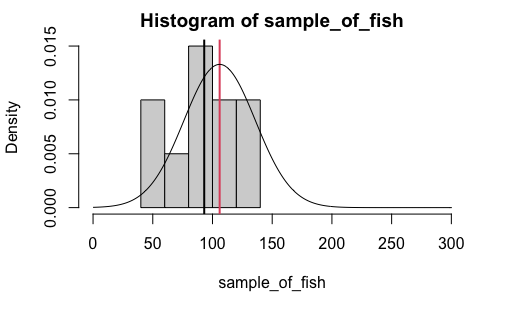

```r
# add a red line for the true population mean
abline(v = 106, col=2,lwd=2)

# add a line showing the true population distribution
x = seq(0,300)
lines(x,dnorm(x = x,mean = 106, sd = 30))
```

**Note**: For the above code to work, you have to run the whole code chunk at once (use the green arrow at the top-right of the chunk)

### Step 3: Mean from many samples

To explore this process, pretend you could repeat this sampling process many times.

Let’s ask R to draw 100 samples of size 10 from this population

For each sample, we’ll calculate it’s mean

Again, use a for-loop

```r
sample_means = rep(NA,100)
for(i in 1:100){ # do 100 experiments
  sample_of_fish = rnorm(n = 10, mean = 106, sd = 30)  # sample 10 fish
  sample_means[i] = mean(sample_of_fish) # record the sample mean
}
sample_means
```

```
  [1] 112.83040 104.49853 119.00198 116.23107 115.24203 100.53818 100.79794
  [8] 116.29266 122.97708 108.76934  89.90214  91.86626 123.75450 119.15586
 [15] 121.75805 100.72773 116.52706 107.88128  96.10820 116.19971 111.30279
 [22] 102.03173 114.30387 100.52364 102.08196 117.23903 101.38356 115.58684
 [29]  98.79637 101.71420  80.17247 110.50820 106.64463 118.51806 107.83202
 [36]  98.26792 121.48955 118.95944  98.18934 104.86021 104.39664 107.55213
 [43] 104.28481 104.58197 101.47297 105.50255  82.46641 101.51151 116.77269
 [50] 109.34988 113.89410  96.02029  91.17626 103.21839  94.65857 109.62615
 [57] 107.40798  96.51830  94.01663  86.27983 106.03962 120.04136 110.21581
 [64]  88.09336  89.13195 115.81899 117.84888 110.68291 110.14503 114.69685
 [71] 109.99397  88.07992  97.11408 115.50104 111.42956  83.66172 107.27208
 [78] 106.85467 114.82147 109.29104 116.60652  90.15895  94.88580 104.12868
 [85] 104.40907  96.78234 110.07491 113.10597 113.07723  94.35738 112.32787
 [92] 105.19331 106.85273 101.60792 113.03587  78.28527 102.71545 117.52580
 [99] 109.48794 104.59189
```

```r
mean(sample_means)˜
```

[output not shown]

The expected distribution of the sample means is a normal distribution with $\mu = 106$ and $\sigma = 30 / \sqrt{n} = 9.49$

**Note**: In R Notebooks, *hover* the mouse over an equation to see it rendered!

## Part 2: Confidence intervals for the mean

This second part of the demonstration explores the creation and interpretation of confidence intervals.

This is based on [this website](http://www.zoology.ubc.ca/~whitlock/kingfisher/CIMean.htm).

Confidence intervals are used to express our uncertainty about an estimate (ex. population mean). The interval gives a range of plausible values for the true mean.

Calculating confidence intervals requires using R’s function for the **t-distribution**

### Student’s t-distribution

The t distribution functions work the same as the normal distribution functions, except it has two additional parameters:

- `df` The degrees of freedom of the t distribution
- `ncp` A non-centrality parameter. Ignore this. We won’t use it.

### Step 3: Calculate a confidence interval

The formula for a confidence interval is: $CI = \bar{y} \pm t_{1-\alpha/2,df}\mbox{SE}$. (Remember to hover your mouse over this equation to see it rendered.)

$t_{1-\alpha/2,df}$ is the **critical value** of the *t* distribution at the $\alpha$ level, with $df$ degrees of freedom.

The Standard Error is $\mbox{SE} = \frac{s}{\sqrt{n}}$

```r
SE = sample_sd / sqrt(n)
```

[output not shown]

```r
length_CI
```

[output not shown]

### Questions:

> If you drew more samples of size 10, how would you expect the length to change? Try it!

> If you drew larger samples (say 30), how would you expect the length to change? Try it!

> If the fish were actually less variable (say sd = 10), how would you expect the length to change? Try it!

## Part 3: The t-test

Lastly, we’ll explore the one-sample t-test, and compare it to the confidence interval

We can perform a one-sample t-test to test the null hypothesis $\mu = 106$. Read the help file for the function `?t.test`

```r
t_test_result = t.test(x=sample_of_fish,  # your data
       y = NULL,          # NULL, because it's a one-sample test (testing mean against known value)
       mu = mu,           # mean of the null hypothesis
       alternative = 'two.sided',     # two-sided alternative hypothesis
       conf.level = 1-alpha    # confidence level (desired frequence)
       )
t_test_result
```

[output not shown]

**Note:** the `t.test` function gives you a confidence interval. Does this match the one you calculated? You can directly extract those numbers like this:

```r
t_test_result$conf.int
```

[output not shown]